# Assign3 writeup

Santina

Sunday, November 02, 2014

In this assignment, we examined a few different linear models that are trained based on different attributes or on data that were imputed.

The source code is loaded here.

```r
source("Assign3_SantinaLin.R")
```

And here’s the summary of all four models in comparison.

```r
kable(summary)
```

[output not shown]

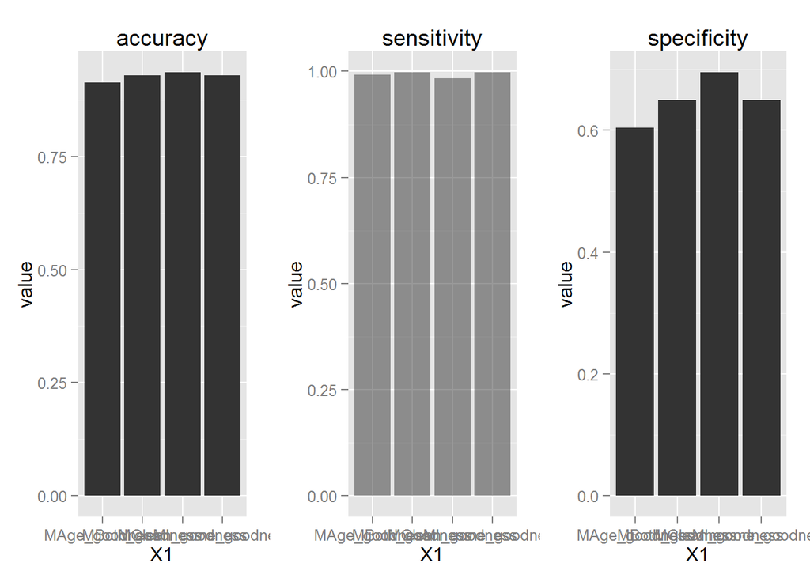

```r
grid.arrange(accuracy_summary, sensitivity_summary, specificity_summary, ncol=3)
```

We can see that MClean has the highest specificity, accuracy, but a slightly lower sensitivity. MClean was trained on the cleaned data set with no missing value, whereas the other three models are trained on the cleaned data set plus the imputed missing values. We can see that using this method to increase the number of training samples don’t always help with the accuracy of a trained model. With the exception of sensitivity, the trained model on imputed data values perform slightly worse than MClean.